# Package Presentation: popbio

Finding eigen vectors and sensativities:

```r
eigA <- eigen.analysis(A)
eigA
```

```
## $lambda1
## [1] 2.004724
##
## $stable.stage
##       seed  jeuvenile  flowering
## 0.92123054 0.05104551 0.02772395
##
## $sensitivities
##                 seed  jeuvenile   flowering
## seed       0.3129057 0.01733815 0.009416733
## jeuvenile  4.7083666 0.26089125 0.141695825
## flowering 14.1621687 0.78472776 0.426203048
##
## $elasticities
##                seed  jeuvenile flowering
## seed      0.0780421 0.00000000 0.2348636
## jeuvenile 0.2348636 0.02602765 0.0000000
## flowering 0.0000000 0.23486360 0.1913394
##
## $repro.value
##      seed jeuvenile flowering
##   1.00000  15.04724  45.26018
##
## $damping.ratio
## [1] 1.614743
```

```r
eigA$stable.stage # w=stable stage distribution
```

```
##       seed  jeuvenile  flowering
## 0.92123054 0.05104551 0.02772395
```

```r
eigA$repro.value # v=reproductive value/contribution to next generation
```

```
##      seed jeuvenile flowering
##   1.00000  15.04724  45.26018
```

```r
eigA$sensitivities # sensitivity matrix -if we change an element in matrix A by a small amount, but hold all other elements constant, what is the change in lambda?
```

```
##                 seed  jeuvenile   flowering
## seed       0.3129057 0.01733815 0.009416733
## jeuvenile  4.7083666 0.26089125 0.141695825
## flowering 14.1621687 0.78472776 0.426203048
```

```r
eigA$elasticities #elasticities: effect of proportional change in vital rates on lambda., like sesitivities, but scaled so that they are demensionless (ie. make values for fecundity and survival more comparable).
```

```
##                seed  jeuvenile flowering
## seed      0.0780421 0.00000000 0.2348636
## jeuvenile 0.2348636 0.02602765 0.0000000
## flowering 0.0000000 0.23486360 0.1913394
```

It looks like the seed to jeuvenile transition is more sensative. So I do a little research and find that seed germination is less successful in wet soils, so you plant your roses in a wet part of the garden:

```r
swampyA <- A
swampyA[2,1] <- 0.05 #instead of 10% germination/year, only 5%
swampyA
```

```
##           seed jeuvenile flowering
## seed      0.50       0.0      50.0
## jeuvenile 0.05       0.2       0.0
## flowering 0.00       0.6       0.9
```

```r
p2 <- pop.projection(swampyA, n, iterations=15)
p2
```

```
## $lambda
## [1] 1.713758
##
## $stable.stage
##       seed  jeuvenile  flowering
## 0.94579041 0.03123518 0.02297441
##
## $stage.vectors
##            0   1     2      3        4         5         6         7
## seed       0 500 700.0 755.00 1492.000 2949.0500 4829.7700 7947.1055
## jeuvenile  0   0  25.0  40.00   45.750   83.7500  164.2025  274.3290
## flowering 10   9   8.1  22.29   44.061   67.1049  110.6444  198.1015
##                    8          9         10        11         12         13
## seed      13878.6262 24083.7492 41038.4993 70147.478 120571.021 206957.189
## jeuvenile   452.2211   784.3755  1361.0626  2324.137   3972.201   6822.991
## flowering   342.8887   579.9325   992.5646  1709.946   2933.434   5023.411
##                   14
## seed      354649.146
## jeuvenile  11712.458
## flowering   8614.865
##
## $pop.sizes
##  [1]     10.000    509.000    733.100    817.290   1581.811   3099.905
##  [7]   5104.617   8419.536  14673.736  25448.057  43392.126  74181.561
## [13] 127476.656 218803.591 374976.469
##
## $pop.changes
##  [1] 50.900000  1.440275  1.114841  1.935434  1.959719  1.646701  1.649396
##  [8]  1.742820  1.734259  1.705125  1.709563  1.718441  1.716421  1.713758
```

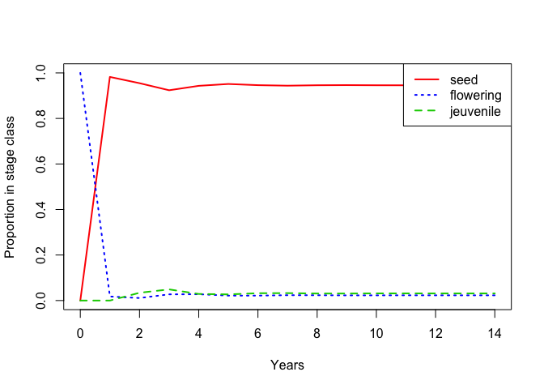

```r
stage.vector.plot(p2$stage.vectors, col=2:4)
```

```r
#still an insane number of flowers!! and lambda is still too big
eigen.analysis(swampyA) #looks like jeuvenille to flowering stange will have large effect on lambda...
```

```
## $lambda1
## [1] 1.714953
##
## $stable.stage
##       seed  jeuvenile  flowering
## 0.94580233 0.03121557 0.02298211
##
## $sensitivities
##                 seed  jeuvenile   flowering
## seed       0.3036929 0.01002318 0.007379453
## jeuvenile  7.3794527 0.24355384 0.179313771
## flowering 18.6325406 0.61495439 0.452753242
##
## $elasticities
##                 seed  jeuvenile flowering
## seed      0.08854263 0.00000000 0.2151503
## jeuvenile 0.21515028 0.02840356 0.0000000
## flowering 0.00000000 0.21515028 0.2376030
##
## $repro.value
##      seed jeuvenile flowering
##   1.00000  24.29906  61.35323
##
## $damping.ratio
## [1] 1.781063
```

What if I do a little more research and find that jeuveniles prefer full sun, so I plant them in a shady part of the garden:

```r
shadyA <- swampyA
shadyA[3,2] <- 0.1 #10% move to flowering each year, rather than 60%
shadyA
```

```
##           seed jeuvenile flowering
## seed      0.50       0.0      50.0
## jeuvenile 0.05       0.2       0.0
## flowering 0.00       0.1       0.9
```

```r
p3 <- pop.projection(shadyA, n, iterations=15)
p3
```

```
## $lambda
## [1] 1.231383
##
## $stable.stage
##       seed  jeuvenile  flowering
## 0.94063953 0.04560079 0.01375968
##
## $stage.vectors
##            0   1     2      3       4         5          6          7
## seed       0 500 700.0 755.00 867.000 1074.0500 1342.27000 1658.35550
## jeuvenile  0   0  25.0  40.00  45.750   52.5000   64.20250   79.95400
## flowering 10   9   8.1   9.79  12.811   16.1049   19.74441   24.19022
##                    8          9         10         11         12
## seed      2038.68870 2507.67421 3087.87685 3803.15494 4683.50704
## jeuvenile   98.90858  121.71615  149.72694  184.33923  227.02559
## flowering   29.76660   36.68079   45.18433   55.63859   68.50866
##                   13        14
## seed      5767.18628 7101.6106
## jeuvenile  279.58047  344.2754
## flowering   84.36035  103.8824
##
## $pop.sizes
##  [1]   10.000  509.000  733.100  804.790  925.561 1142.655 1426.217
##  [8] 1762.500 2167.364 2666.071 3282.788 4043.133 4979.041 6131.127
## [15] 7549.768
##
## $pop.changes
##  [1] 50.900000  1.440275  1.097790  1.150065  1.234554  1.248161  1.235787
##  [8]  1.229710  1.230099  1.231321  1.231616  1.231481  1.231387  1.231383
```

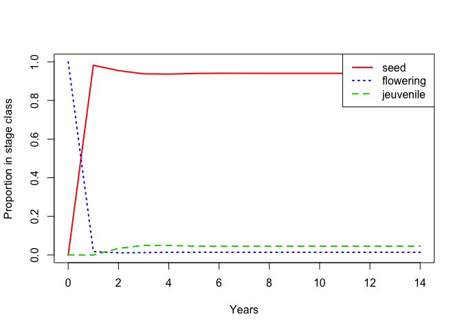

```r
stage.vector.plot(p3$stage.vectors, col=2:4)
```

```r
eigen.analysis(shadyA)
```

```
## $lambda1
## [1] 1.231402
##
## $stable.stage
##       seed  jeuvenile  flowering
## 0.94064021 0.04560006 0.01375973
##
## $sensitivities
##                 seed  jeuvenile   flowering
## seed       0.2553544 0.01237899 0.003735336
## jeuvenile  3.7353361 0.18108045 0.054640670
## flowering 38.5263433 1.86766803 0.563565146
##
## $elasticities
##                seed  jeuvenile flowering
## seed      0.1036844 0.00000000 0.1516700
## jeuvenile 0.1516700 0.02941045 0.0000000
## flowering 0.0000000 0.15167001 0.4118951
##
## $repro.value
##      seed jeuvenile flowering
##   1.00000  14.62805 150.87401
##
## $damping.ratio
## [1] 2.34347
```

```r
#much better!

p$lambda
```

```
## [1] 2.000312
```

```r
p2$lambda
```

```
## [1] 1.713758
```

```r
p3$lambda
```

```
## [1] 1.231383
```

Looks like I’ll be planting my roses in a shady swamp.